# p-valueの計算方法と可視化

UPDATE: 2023-02-16 11:59:37

# はじめに

p値とは「特定の統計モデルのもとで(帰無仮説が真であると仮定することも含む)、観察されたデータの統計的要約が観察された値と同じか、それよりも極端である場合の確率」と説明される。p値が利用されるのは、帰無仮説有意検定(NHST)を行うときであり、p値の解釈については誤用が絶えない。これは自分にも当てはまることなので、強い自戒の意味を込めてp値についておさらいする。

検定とp値に関する誤解は絶えず、下記の通り、ASA(American Statistical Association)が声明を出していたりする。京都大学の佐藤先生が日本語版でまとめてくださっているので、詳細は下記を参考に願います。

- [Wasserstein RL, Lazar NA. Editorial: The ASA’s statement on p-values: Context, process, and purpose. The American Statistician 2016; 70: 129-133.](https://www.tandfonline.com/doi/full/10.1080/00031305.2016.1154108)
- [統計的有意性と P 値に関する ASA 声明](https://biometrics.gr.jp/news/all/ASA.pdf)
- [ASA声明と疫学研究における P 値](https://www.jstage.jst.go.jp/article/jjb/38/2/38_109/_pdf)
- [京都大学大学院医学研究科 聴講コース 臨床研究者のための生物統計学「仮説検定とP値の誤解」佐藤 俊哉 医学研究科教授](https://www.youtube.com/watch?v=vz9cZnB1d1c)

ここでの目標は、平均値の差の検定を例にp値の計算過程を明らかにし、可視化するところまで。今後は、個人的には最近よく聞くようになった「p値関数」についてまとめたい。

## サンプルデータ

下記のような試験のスコアが観測されたとする。ここでは、等分散の正規母集団からのサンプルデータとする。

両グループはある程度、重なっている部分もあるが、赤色のグループAの方が平均値は高そうではある。

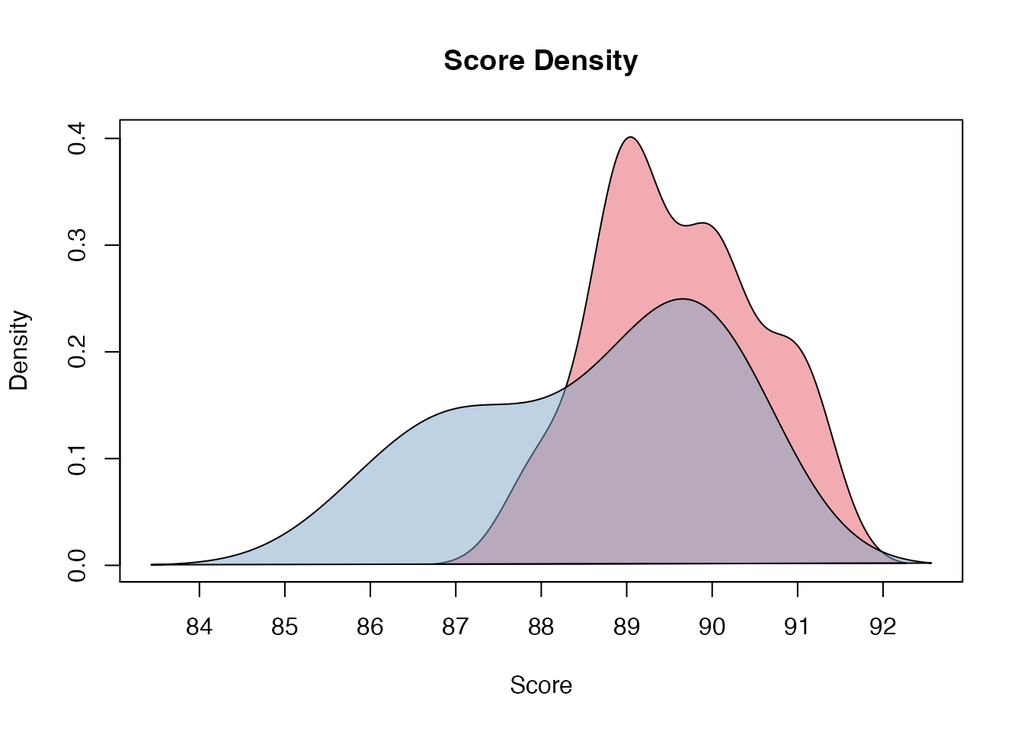

```r
set.seed(1989)
A <- floor(rnorm(10, 90, 1))
B <- floor(rnorm(10, 89, 1))
#A <- c(9,7,8,9,8,9,9,10,9,9)
#B <- c(9,6,7,8,7,9,8,8,8,7)
A_density <- density(A)
B_density <- density(B)

plot(
  range(A_density$x, B_density$x),
  range(A_density$y, B_density$y),
  type = "n",
  xlab = "Score",
  ylab = "Density",
  xaxt = "n")
axis(1, at = seq(min(A, B)-10, max(A, B)+10, by = 1))

polygon(A_density, col = adjustcolor("#E55A64", alpha.f = 0.5))
polygon(B_density, col = adjustcolor("#7FA6C9", alpha.f = 0.5))
title("Score Density")
```

```r
summary(A);
```

```
##    Min. 1st Qu.  Median    Mean 3rd Qu.    Max.
##    88.0    89.0    89.5    89.6    90.0    91.0
```

```r
summary(B)
```

```
##    Min. 1st Qu.  Median    Mean 3rd Qu.    Max.
##   86.00   87.25   89.00   88.60   90.00   90.00
```

## 仮説検定

天下り的ではあるが、このような2グループの平均値を比較する場合、t検定を行うことになる。つまり、各グループの平均、分散(標準偏差)、サンプルサイズを利用して、t分布(自由度は18)に従うt値を計算することで、2グループ間のスコアの差が0より大きい(小さい)確率を調べる。この過程でp値も計算することができる。

仮説検定では、特定の統計モデルのもとで(帰無仮説が真であると仮定することも含む)、観察されたデータの統計的要約が観察された値と同じか、それよりも極端である場合の確率を計算するが、それがp値である。

ちなみに、ここで利用するt分布(自由度は18)は下記のような形状をしている。

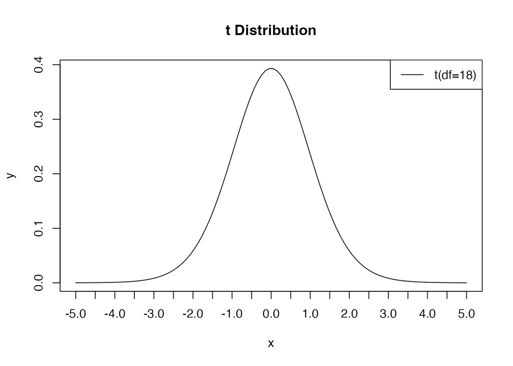

```r
df <- (length(A) + length(B) - 2)
x <- seq(-5, 5, length.out = 100)
y <- dt(x, df = df)
plot(x,
     y,
     type = "l",
  xaxt = "n")
axis(1, at = seq(min(x), max(x), by = .5))
title("t Distribution")
legend("topright",
       paste0("t(df=", df, ")"),
       lty = 1)
```

## t検定

計算式に従って、計算してもt値は計算できるが、`t.test()`でt検定は簡単に実行でき、t値を得られる。

```r
ttest_res <- t.test(A, B, var.equal = TRUE)
ttest_res
```

```
##
##  Two Sample t-test
##
## data:  A and B
## t = 1.7678, df = 18, p-value = 0.09405
## alternative hypothesis: true difference in means is not equal to 0
## 95 percent confidence interval:
##  -0.188461  2.188461
## sample estimates:
## mean of x mean of y
##      89.6      88.6
```

t値は1.767767で、p値は0.094047である。t値はt統計量を計算する計算式から算出され、p値は検定に使用しているt分布から計算できる。

そもそもp値は、「特定の統計モデルのもとで(帰無仮説が真であると仮定することも含む)、観察されたデータの統計的要約が観察された値と同じか、それよりも極端である場合の確率」だった。ここでは、帰無仮説のスコアの差が0であるという仮定は、先ほど紹介した0を中心とするt分布によって表現されている。

つまり、このt分布からp値を計算でき、さきほどt検定によって得られたt値に対応するt分布の両側の赤色部分の確率がp値に対応しているためである。

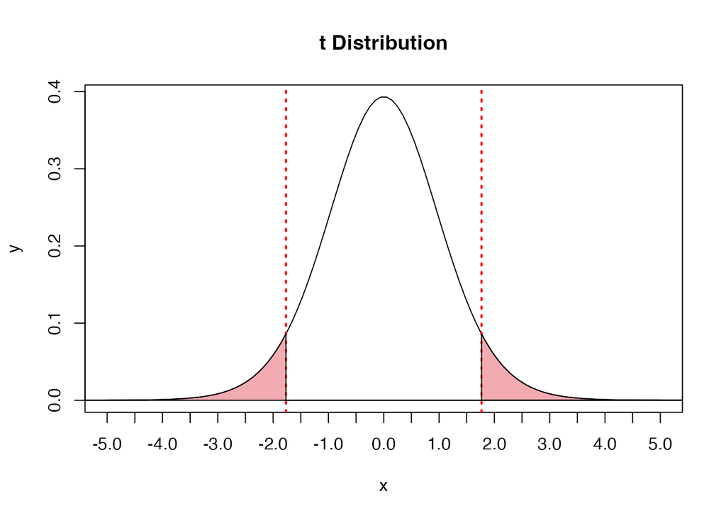

```r
plot(x,
     y,
     type = "l",
  xaxt = "n")
axis(1, at = seq(min(x), max(x), by = .5))
title("t Distribution")
abline(v = ttest_res$statistic, lwd = 2, col = "red", lty = 3)
abline(v = -1*ttest_res$statistic, lwd = 2, col = "red", lty = 3)

xx_upr <- seq(ttest_res$statistic, 10, length=100)
xx_lwr <- seq(-1*ttest_res$statistic, -10, length=100)
z <- dt(xx_upr, df = df)
polygon(c(ttest_res$statistic, xx_upr, 8),
        c(0, z, 0),
        col = adjustcolor("#E55A64", alpha.f = 0.5))
polygon(c(-1*ttest_res$statistic, xx_lwr ,8),
        c(0, z, 0),
        col = adjustcolor("#E55A64", alpha.f = 0.5))
```

下側t値に対応する外側確率は`pt()`によって得られ、

```r
prob_lwr <- pt(-1 * ttest_res$statistic, df = df)
prob_lwr
```

```
##          t
## 0.04702348
```

```r
prob_upr <- 1 - pt(ttest_res$statistic, df = df)
prob_upr
```

```
##          t
## 0.04702348
```

これらの確率を足し合わせると、t検定で得られたp値の確率0.094047が計算できる。

```r
prob_lwr + prob_upr
```

```
##          t
## 0.09404695
```

帰無仮説のt分布がわかっているので、積分してももちろん同じ結果が得られる。

```r
integral_lwr <- integrate(f = dt, df = df, lower = -Inf, upper = -1 * ttest_res$statistic)$value
integral_upr <- 1 - integrate(f = dt, df = df, lower = -Inf, upper = ttest_res$statistic)$value
sprintf("p-value: %f", (integral_lwr + integral_upr))
```

```
## [1] "p-value: 0.094047"
```

これを可視化すると下記のような形となる。黒線は赤色の部分が合計で5％となるt値である。黒線よりも赤線が内側にある、つまりp値は5%以上あることがわかる。実際、10%近くあるため、観察されたデータが少なくとも同じか、極端な値ではないということになる。

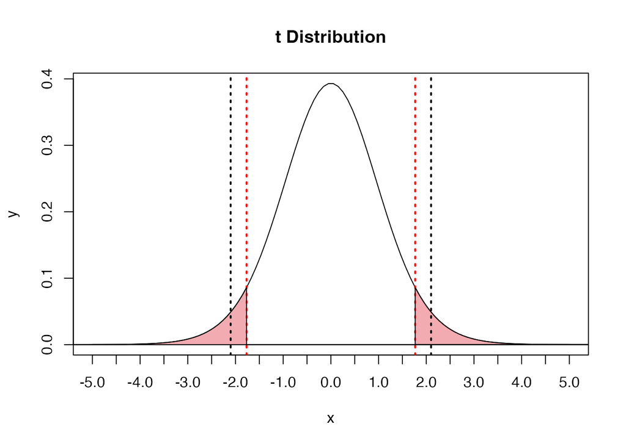

```r
plot(x,
     y,
     type = "l",
  xaxt = "n")
axis(1, at = seq(min(x), max(x), by = .5))
title("t Distribution")
abline(v = ttest_res$statistic, lwd = 2, col = "red", lty = 3)
abline(v = -1*ttest_res$statistic, lwd = 2, col = "red", lty = 3)

xx_upr <- seq(ttest_res$statistic, 10, length=100)
xx_lwr <- seq(-1*ttest_res$statistic, -10, length=100)
z <- dt(xx_upr, df = df)
polygon(c(ttest_res$statistic, xx_upr, 8),
        c(0, z, 0),
        col = adjustcolor("#E55A64", alpha.f = 0.5))
polygon(c(-1*ttest_res$statistic, xx_lwr ,8),
        c(0, z, 0),
        col = adjustcolor("#E55A64", alpha.f = 0.5))

abline(v = qt(0.025, df = df), lwd = 2, col = "black", lty = 3)
abline(v = qt(0.975, df = df), lwd = 2, col = "black", lty = 3)
```

## まとめ

p値は仮説検定において、「特定の統計モデルのもとで、帰無仮説が真であると仮定した場合に、観察されたデータが少なくとも同じか、もっと極端である場合の確率」である。 仮説検定では、帰無仮説が真であること仮定しているため、帰無仮説に応じた確率分布が必要になる。例えば、t検定の場合はt分布によってスコアの差が0であることを表現する。そこから仮説検定を行って得られた統計量の値を利用し、帰無仮説に利用している確率分布から、観測データから得られた統計量の値よりも極端な確率を計算する。これがp値に対応している。